# Exploring a Bulk RNA-Seq Counts Matrix

Jonah

August 19, 2026

## Part 1: Loading and getting to know the data

I am first loading the counts matrix and the features table into R

```r
counts <- readRDS("results/dataset/counts.rds")
features <- readRDS("results/dataset/features.rds")
```

Both the counts matrix and the features table loaded successfully without an error.

### Checking the object types

I am checking what type of R object was created from each file.

```r
class(counts)
```

```
## [1] "matrix" "array"
```

```r
class(features)
```

```
## [1] "data.frame"
```

The counts object is a matrix and array. Need to ask Helena what that means. GPT says that it just means it is 2-D structure with rows and columns.The features table comes back data.frame. This may mean it is a it describes the features of the matrix rows.

### Checking the size of the counts matrix

I am checking the dimesniosn of the counts matrix to determine how many feautures and samples it contains.

```r
dim(counts)
```

```
## [1] 89118   181
```

Seems like 89118 rows and 181 columns. The rows are the Genes/HERVS and the columns are individual samples

### Previewing the counts matrix

I guess this displays the first 5 rows and columns to see the matrix and how the data looks

```r
counts[1:5, 1:5]
```

```
##             SCZ47_GSM7796488 SCZ46_GSM7796487 SCZ45_GSM7796486 SCZ44_GSM7796485
## DDX11L1                    0                0                0                0
## WASH7P                     4                4                7                4
## MIR6859-1                  0                0                1                0
## MIR1302-2HG                0                0                0                0
## MIR1302-2                  0                0                0                0
##             SCZ43_GSM7796484
## DDX11L1                    1
## WASH7P                     4
## MIR6859-1                  0
## MIR1302-2HG                0
## MIR1302-2                  0
```

This is pretty cool. On the top we have the indivudal people and the left is probably the HERVS or genes or whatever. The first sections of the matrix contains mostly zero or low counts. One feature had counts between 4-7 which is the highest compared to other samples. Most features had zero counts in their samples. This shows that features may not be detected in many samples.

### Examining the feature names

I am examining the first and last 20 row names to look for patterns in how they are labeled

```r
head(rownames(counts), 20)
```

```
##  [1] "DDX11L1"       "WASH7P"        "MIR6859-1"     "MIR1302-2HG"
##  [5] "MIR1302-2"     "FAM138A"       "OR4G4P"        "OR4G11P"
##  [9] "OR4F5"         "RP11-34P13.7"  "RP11-34P13.8"  "CICP27"
## [13] "RP11-34P13.15" "RP11-34P13.16" "RP11-34P13.14" "RP11-34P13.13"
## [17] "RNU6-1100P"    "RP11-34P13.9"  "DDX11L17"      "WASH9P"
```

```r
tail(rownames(counts), 20)
```

```
##  [1] "MER4_Un_GL000213v1"    "HML1_Un_GL000214v1"    "HML3_Un_GL000214v1"
##  [4] "HML3_Un_GL000218v1"    "HML1_Un_GL000218v1"    "HERVL40_Un_GL000220v1"
##  [7] "HERVL66_Un_GL000220v1" "ERVLB4_Un_GL000220v1"  "MER101_Un_GL000224v1"
## [10] "HERV3_Un_GL000224v1"   "PRIMA41_Un_KI270442v1" "MER101_Un_KI270741v1"
## [13] "HERV3_Un_KI270741v1"   "HML3_Un_KI270742v1"    "HML1_Un_KI270742v1"
## [16] "HML1_Un_KI270743v1"    "HML3_Un_KI270743v1"    "MER4_Un_KI270743v1"
## [19] "HML3_Un_KI270751v1"    "HML1_Un_KI270751v1"
```

Row names with HERV before it seem to be HERVS. I am not familiar with what LINES and CG look like.

```r
head(rownames(counts))
```

```
## [1] "DDX11L1"     "WASH7P"      "MIR6859-1"   "MIR1302-2HG" "MIR1302-2"
## [6] "FAM138A"
```

```r
tail(rownames(counts))
```

```
## [1] "HML1_Un_KI270742v1" "HML1_Un_KI270743v1" "HML3_Un_KI270743v1"
## [4] "MER4_Un_KI270743v1" "HML3_Un_KI270751v1" "HML1_Un_KI270751v1"
```

```r
#rownames(counts)
```

### Examining the samples names

```r
colnames(counts)
```

```
##   [1] "SCZ47_GSM7796488" "SCZ46_GSM7796487" "SCZ45_GSM7796486"
##   [4] "SCZ44_GSM7796485" "SCZ43_GSM7796484" "SCZ42_GSM7796483"
##   [7] "SCZ41_GSM7796482" "SCZ40_GSM7796481" "SCZ39_GSM7796480"
##  [10] "SCZ38_GSM7796479" "SCZ37_GSM7796478" "SCZ36_GSM7796477"
##  [13] "SCZ35_GSM7796476" "SCZ34_GSM7796475" "SCZ33_GSM7796474"
##  [16] "SCZ32_GSM7796473" "SCZ31_GSM7796472" "SCZ30_GSM7796471"
##  [19] "SCZ29_GSM7796470" "SCZ28_GSM7796469" "SCZ27_GSM7796468"
##  [22] "SCZ26_GSM7796467" "SCZ25_GSM7796466" "SCZ24_GSM7796465"
##  [25] "SCZ71_GSM7796512" "SCZ70_GSM7796511" "SCZ69_GSM7796510"
##  [28] "SCZ68_GSM7796509" "SCZ67_GSM7796508" "SCZ66_GSM7796507"
##  [31] "SCZ65_GSM7796506" "SCZ64_GSM7796505" "SCZ63_GSM7796504"
##  [34] "SCZ62_GSM7796503" "SCZ61_GSM7796502" "SCZ60_GSM7796501"
##  [37] "SCZ59_GSM7796500" "SCZ58_GSM7796499" "SCZ57_GSM7796498"
##  [40] "SCZ56_GSM7796497" "SCZ55_GSM7796496" "SCZ54_GSM7796495"
##  [43] "SCZ53_GSM7796494" "SCZ52_GSM7796493" "SCZ51_GSM7796492"
```

[output cut: 46 more lines]

SCZ = Schizophrenia Con = Healthy GSM = ???

```r
ncol(counts)
```

```
## [1] 181
```

```r
grepl("SCZ", colnames(counts))
```

```
##   [1]  TRUE  TRUE  TRUE  TRUE  TRUE  TRUE  TRUE  TRUE  TRUE  TRUE  TRUE  TRUE
##  [13]  TRUE  TRUE  TRUE  TRUE  TRUE  TRUE  TRUE  TRUE  TRUE  TRUE  TRUE  TRUE
##  [25]  TRUE  TRUE  TRUE  TRUE  TRUE  TRUE  TRUE  TRUE  TRUE  TRUE  TRUE  TRUE
##  [37]  TRUE  TRUE  TRUE  TRUE  TRUE  TRUE  TRUE  TRUE  TRUE  TRUE  TRUE  TRUE
##  [49] FALSE FALSE FALSE FALSE FALSE FALSE FALSE FALSE FALSE FALSE FALSE FALSE
##  [61] FALSE FALSE FALSE FALSE FALSE FALSE FALSE FALSE FALSE FALSE FALSE FALSE
##  [73] FALSE FALSE FALSE FALSE FALSE FALSE FALSE FALSE FALSE FALSE FALSE FALSE
##  [85] FALSE FALSE FALSE FALSE FALSE FALSE FALSE FALSE FALSE FALSE FALSE FALSE
##  [97]  TRUE  TRUE  TRUE  TRUE  TRUE  TRUE  TRUE  TRUE  TRUE  TRUE  TRUE  TRUE
## [109]  TRUE  TRUE  TRUE  TRUE  TRUE  TRUE  TRUE  TRUE  TRUE  TRUE  TRUE  TRUE
## [121]  TRUE  TRUE  TRUE  TRUE  TRUE  TRUE  TRUE  TRUE  TRUE  TRUE  TRUE  TRUE
## [133] FALSE FALSE FALSE FALSE FALSE FALSE FALSE FALSE FALSE FALSE FALSE FALSE
## [145] FALSE FALSE FALSE FALSE FALSE FALSE FALSE FALSE FALSE FALSE FALSE FALSE
## [157] FALSE FALSE FALSE FALSE FALSE FALSE FALSE FALSE FALSE FALSE FALSE FALSE
## [169] FALSE FALSE FALSE FALSE FALSE FALSE FALSE FALSE FALSE FALSE FALSE FALSE
## [181] FALSE
```

```r
sum(grepl("SCZ", colnames(counts)))
```

```
## [1] 84
```

```r
sum(grepl("CON", colnames(counts)))
```

```
## [1] 97
```

The matrix contains 181 samples. 84 schizophrenia samples and 97 control samples.

```r
head(features)
```

```
##     gene.name gene.type
## 1     DDX11L1        CG
## 2      WASH7P        CG
## 3   MIR6859-1        CG
## 4 MIR1302-2HG        CG
## 5   MIR1302-2        CG
## 6     FAM138A        CG
```

```r
tail(features)
```

```
##                gene.name gene.type
## 89113 HML1_Un_KI270742v1       LTR
## 89114 HML1_Un_KI270743v1       LTR
## 89115 HML3_Un_KI270743v1       LTR
## 89116 MER4_Un_KI270743v1       LTR
## 89117 HML3_Un_KI270751v1       LTR
## 89118 HML1_Un_KI270751v1       LTR
```

```r
dim(features)
```

```
## [1] 89118     2
```

```r
table(features$gene.type)
```

```
##
##    CG  LINE   LTR
## 60605 13545 14968
```

```r
dim(features[which(features$gene.name == "DNAJC8"), ])
```

```
## [1] 1 2
```

The features table classifies 60,605 features as CG, 13,545 as LINE elements, and 14,968 as LTR/HERV elements.

### Comparing the features table with the counts matrix

```r
nrow(features) == nrow(counts)
```

```
## [1] TRUE
```

Both the features table and the counts matrix contain 89,118 rows.

## Part 2: Playing with the matrix

### Accessing a specific count

I am retrieving the RNA-seq count for the WASH7P feature to practice selecting one matrix.

```r
counts["WASH7P", "SCZ47_GSM7796488"]
```

```
## [1] 4
```

The WASH7P count in the sample was 4.

### Examining WASH7P across all samples

I am getting the WASH7P row to examine its expression across all 181 samples. Then make into bar plot.

```r
wash7p_counts <- counts["WASH7P", ]

wash7p_counts
```

```
## SCZ47_GSM7796488 SCZ46_GSM7796487 SCZ45_GSM7796486 SCZ44_GSM7796485
##                4                4                7                4
## SCZ43_GSM7796484 SCZ42_GSM7796483 SCZ41_GSM7796482 SCZ40_GSM7796481
##                4                1               10                5
## SCZ39_GSM7796480 SCZ38_GSM7796479 SCZ37_GSM7796478 SCZ36_GSM7796477
##               13                3                5                9
## SCZ35_GSM7796476 SCZ34_GSM7796475 SCZ33_GSM7796474 SCZ32_GSM7796473
##                4               10                6                8
## SCZ31_GSM7796472 SCZ30_GSM7796471 SCZ29_GSM7796470 SCZ28_GSM7796469
##                3                1                4                3
## SCZ27_GSM7796468 SCZ26_GSM7796467 SCZ25_GSM7796466 SCZ24_GSM7796465
##                7               13                1                5
## SCZ71_GSM7796512 SCZ70_GSM7796511 SCZ69_GSM7796510 SCZ68_GSM7796509
##                2               23                3                4
## SCZ67_GSM7796508 SCZ66_GSM7796507 SCZ65_GSM7796506 SCZ64_GSM7796505
##               13                7                3                2
## SCZ63_GSM7796504 SCZ62_GSM7796503 SCZ61_GSM7796502 SCZ60_GSM7796501
##                6                9               16               13
## SCZ59_GSM7796500 SCZ58_GSM7796499 SCZ57_GSM7796498 SCZ56_GSM7796497
##                2                2                9                3
## SCZ55_GSM7796496 SCZ54_GSM7796495 SCZ53_GSM7796494 SCZ52_GSM7796493
##               12                5                6                6
## SCZ51_GSM7796492 SCZ50_GSM7796491 SCZ49_GSM7796490 SCZ48_GSM7796489
##               11                1               15                3
## CON96_GSM7796440 CON95_GSM7796439 CON94_GSM7796438 CON93_GSM7796437
##                5                3                3               11
## CON92_GSM7796436 CON91_GSM7796435 CON90_GSM7796434 CON89_GSM7796433
##               13                4                6                1
## CON88_GSM7796432 CON87_GSM7796431 CON86_GSM7796430 CON85_GSM7796429
##               15               12                9               17
## CON84_GSM7796428 CON83_GSM7796427 CON82_GSM7796426 CON81_GSM7796425
##                8                0               16                6
## CON80_GSM7796424 CON79_GSM7796423 CON78_GSM7796422 CON77_GSM7796421
##                4                5                0                6
## CON76_GSM7796420 CON75_GSM7796419 CON74_GSM7796418 CON73_GSM7796417
##                9                8                6               12
## CON72_GSM7796416 CON71_GSM7796415 CON70_GSM7796414 CON69_GSM7796413
##                7               10                6                6
## CON68_GSM7796412 CON67_GSM7796411 CON66_GSM7796410 CON65_GSM7796409
##                3                2               19                3
```

[output cut: 37 more lines]

```
##                6                4               10                4
## CON25_GSM7796369 CON24_GSM7796368 CON23_GSM7796367 CON22_GSM7796366
##               11                2                4                2
## CON21_GSM7796365 CON20_GSM7796364 CON19_GSM7796363 CON18_GSM7796362
##                6                3                7                6
## CON17_GSM7796361 CON16_GSM7796360 CON15_GSM7796359 CON14_GSM7796358
##                4                3               16                2
## CON13_GSM7796357 CON12_GSM7796356 CON11_GSM7796355 CON10_GSM7796354
##                4               12               10                6
##  CON9_GSM7796353  CON8_GSM7796352  CON7_GSM7796351  CON6_GSM7796350
##               13                2                4                3
##  CON5_GSM7796349  CON4_GSM7796348  CON3_GSM7796347  CON2_GSM7796346
##                2                1               12                0
##  CON1_GSM7796345
##                4
```

```r
mean(wash7p_counts)
```

```
## [1] 7.088398
```

```r
max(wash7p_counts)
```

```
## [1] 30
```

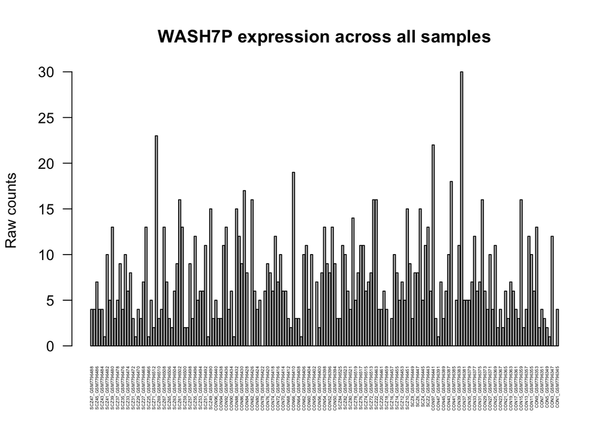

```r
barplot(
  wash7p_counts,
  las = 2,
  cex.names = 0.3,
  main = "WASH7P expression across all samples",
  ylab = "Raw counts"
)
```

```r
mean(wash7p_counts)
```

```
## [1] 7.088398
```

```r
max(wash7p_counts)
```

```
## [1] 30
```

WASH7P expression varied. Most samples had low raw counts. Some had much higher expression though The mean count was 7.088, and the maximum count was 30.

### Examining DDX11L1 across all samples

Helena wants me to sample another gene and write what I see. I will compare DDX11L1 expression across all samples and its distribution with WASH7P.

```r
ddx11l1_counts <- counts["DDX11L1", ]

mean(ddx11l1_counts)
```

```
## [1] 0.6022099
```

```r
max(ddx11l1_counts)
```

```
## [1] 7
```

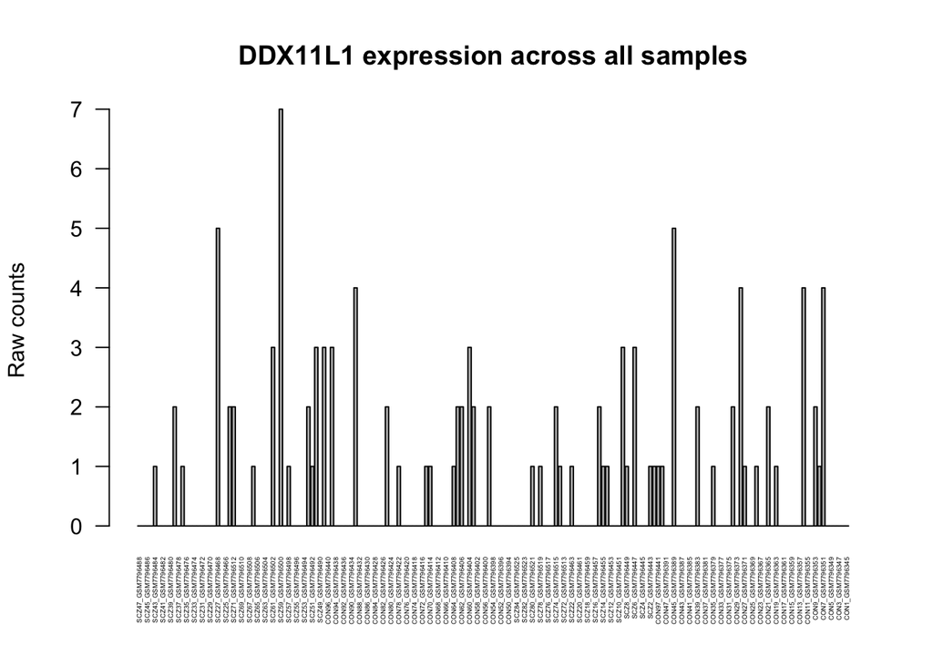

```r
barplot(
  ddx11l1_counts,
  las = 2,
  cex.names = 0.3,
  main = "DDX11L1 expression across all samples",
  ylab = "Raw counts"
)
```

```r
c(
  mean = mean(ddx11l1_counts),
  maximum = max(ddx11l1_counts)
)
```

```
##      mean   maximum
## 0.6022099 7.0000000
```

DDX11L1 had a mean raw count of 0.60 and a maximum count of 7. Its expression was much lower than WASH7P.

### Examining a single sample

I am examining all 89,118 features in one sample.

```r
scz47 <- counts[, "SCZ47_GSM7796488"]

zero_features <- sum(scz47 == 0)
zero_fraction <- sum(scz47 == 0) / length(scz47)

c(
  zero_features = zero_features,
  zero_fraction = zero_fraction
)
```

```
## zero_features zero_fraction
##  5.829400e+04  6.541215e-01
```

```r
scz47 <- counts[, "SCZ47_GSM7796488"]

zero_features <- sum(scz47 == 0)
zero_fraction <- sum(scz47 == 0) / length(scz47)

c(
  zero_features = zero_features,
  zero_fraction = zero_fraction
)
```

```
## zero_features zero_fraction
##  5.829400e+04  6.541215e-01
```

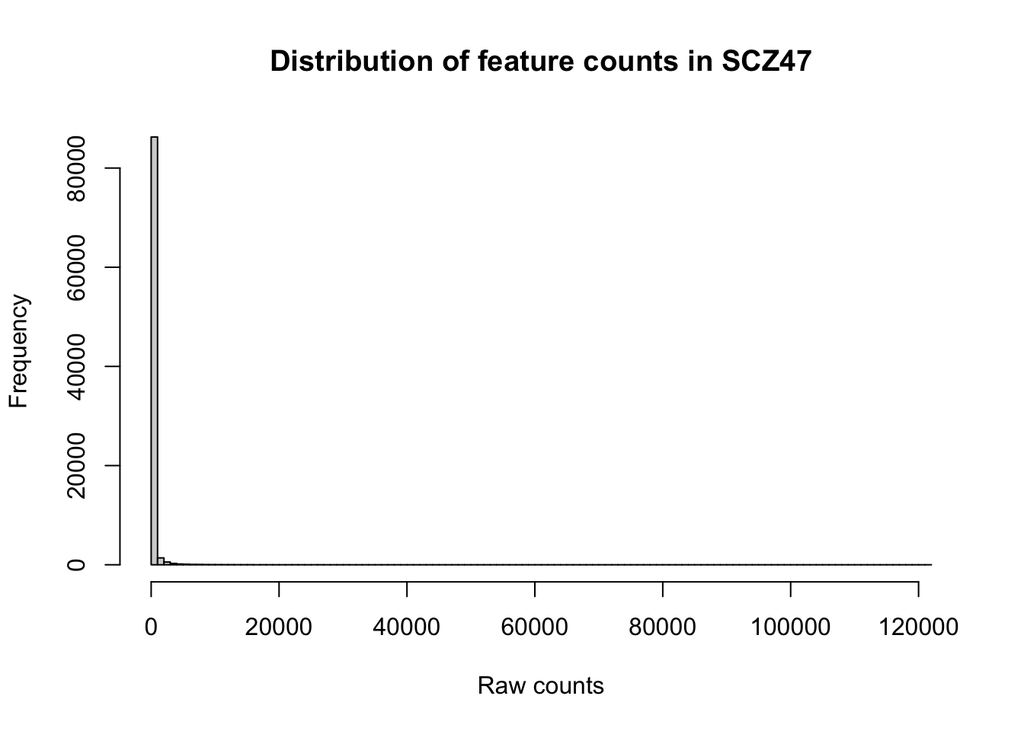

```r
hist(
  scz47,
  breaks = 100,
  main = "Distribution of feature counts in SCZ47",
  xlab = "Raw counts"
)
```

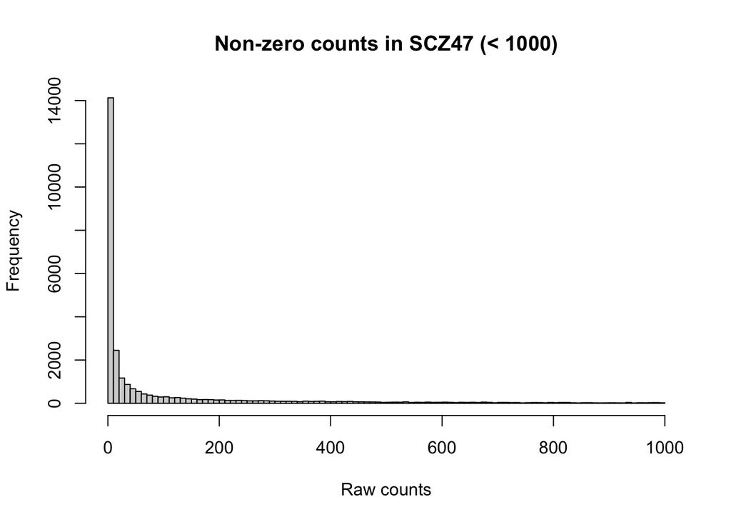

```r
hist(
  scz47[scz47 > 0 & scz47 < 1000],
  breaks = 100,
  main = "Non-zero counts in SCZ47 (< 1000)",
  xlab = "Raw counts"
)
```

In the sample 58,294 genes had zero counts which is 65.41% of all features. This indicates that most features in the matrix were not detected in this PBMC sample. This is reasonable because not every gene or transposable element is active.

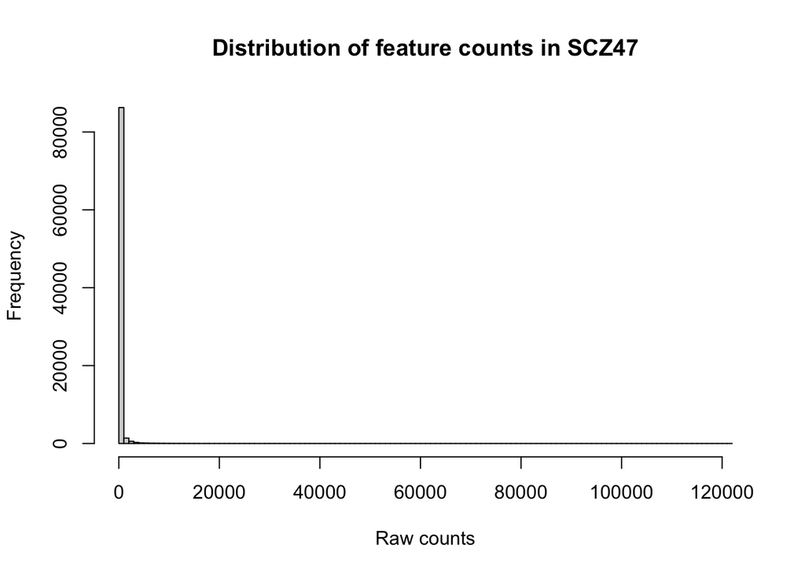

```r
hist(
  scz47,
  breaks = 100,
  main = "Distribution of feature counts in SCZ47",
  xlab = "Raw counts"
)
```

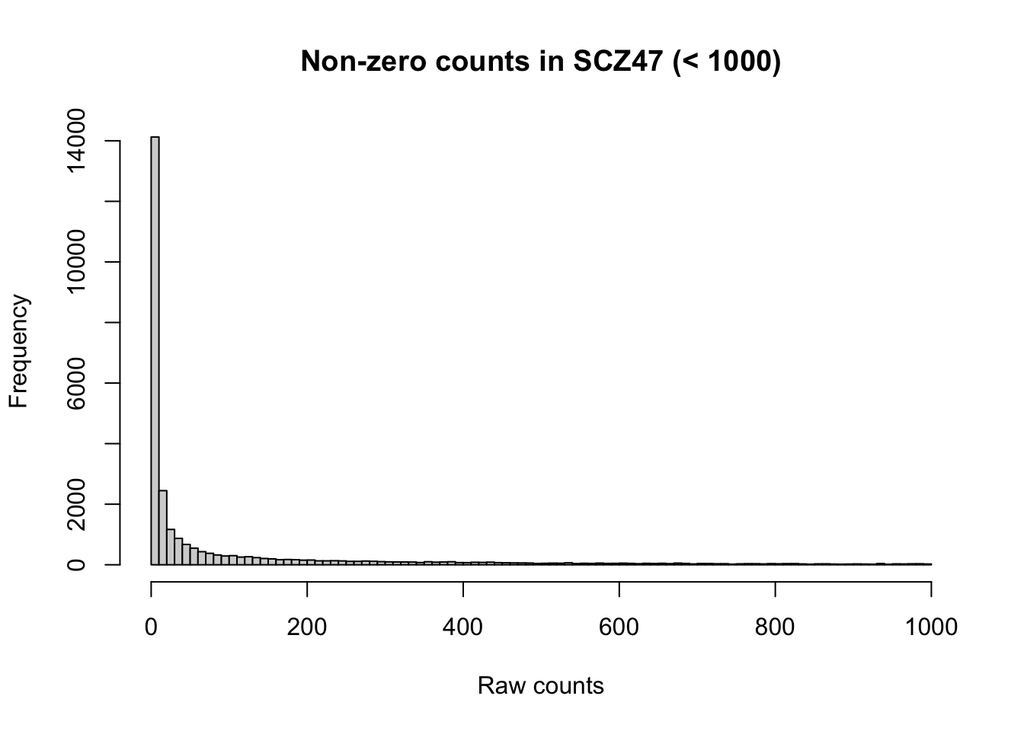

```r
hist(
  scz47[scz47 > 0 & scz47 < 1000],
  breaks = 100,
  main = "Non-zero counts in SCZ47 (< 1000)",
  xlab = "Raw counts"
)
```

Most features had zero or low raw counts, while a small number had extremely high counts reaching 120,000.

```r
lib_sizes <- colSums(counts)
summary(lib_sizes)
```

```
##     Min.  1st Qu.   Median     Mean  3rd Qu.     Max.
## 10393044 13237722 14069168 14579497 15294177 22204070
```

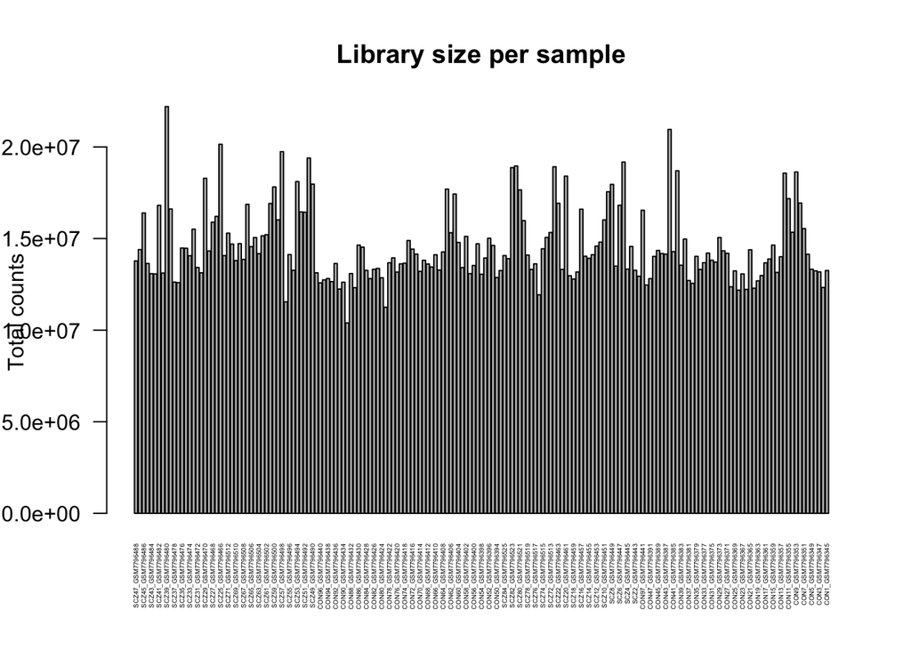

```r
barplot(
  lib_sizes,
  las = 2,
  cex.names = 0.3,
  main = "Library size per sample",
  ylab = "Total counts"
)
```

Library Defintion - total number of RNA-seq reads counted in one sample—the sum of all values in that sample’s column. The sample library sizes ranged from 10000000 to 22000000 total counts. Most samples had broadly similar library sizes, although several samples had noticeably higher totals.

### Calculating total counts for each feature

I am summing each feature’s counts across all 181 samples. I will identify the 20 features with the highest total expression and determine how many features have zero counts in every sample.

```r
gene_totals <- rowSums(counts)

top_20_features <- tail(sort(gene_totals), 20)
top_20_features
```

```
##   TMSB4X    PTPRC   MT-CO3   MT-CO2     MCL1   S100A9   EEF1A1      FTL
##  7270467  7321494  7421169  7773680  8538297  8915939  8961309  9065997
##    NAMPT    DUSP1    HLA-E   MT-ND4    HLA-C    HLA-B    CSF3R    TXNIP
## 10348755 10681226 10796250 11188161 12045949 12856202 13503879 14079859
##   MT-CO1  MT-RNR2     ACTB      B2M
## 18415057 18560459 18906362 24090715
```

```r
sum(gene_totals == 0)
```

```
## [1] 9532
```

The most highly expressed feature across all samples was B2M. A total of 9,532 features had zero counts across every sample. These completely undetected features provide no information for comparing samples and should be removed.

## Checkpoint: What I Have Learned So Far

The dataset contains raw RNA-seq counts from PBMC samples. The rows represent genes, LINE elements, and HERV elements. The columns represent individual samples.

The features include: 60,605 canonical genes, 13,545 LINE elements, 14,968 LTR/HERV elements**

For WASH7P:

Count in sample SCZ47: 4 Mean across all samples: 7.09 Maximum: 30

For DDX11L1:

Mean across all samples: 0.60 Maximum: 7

WASH7P generally had higher raw counts than DDX11L1.

### The SCZ47 sample

In SCZ47: 58,294 features had zero counts. This was 65.41% of all features.

The histograms showed that most features had zero or low counts, while a small number had extremely high counts.

Library size is the total number of RNA-seq counts in one sample.

- Minimum: ~ 10,000,000
- Median: ~ 14,000,000
- Mean: ~ 14,000,000
- Maximum: ~ 22,000,000

Most samples had similar library sizes.

### Total expression across all samples

`B2M` was the most highly expressed feature, with 24,090,715 total counts.

Other highly expressed features included genes such as HLA genes.

A total of 9,532 features, or approximately 10.7%, had zero counts in every sample.

### Main conclusion

We must filter out the stuff that is useless to me now.

### Free exploration

Helena wants me to do a bunch of questions. I need to now investigate how many features had high or extremely low total counts across all 181 samples.

```r
sum(gene_totals > 1000)
```

```
## [1] 20325
```

```r
sum(gene_totals > 100)
```

```
## [1] 35165
```

```r
sum(gene_totals < 10)
```

```
## [1] 23470
```

```r
head(sort(scz47, decreasing = TRUE), 10)
```

```
##     B2M  MT-CO1   CSF3R MT-RNR2   TXNIP    ACTB   NAMPT  MT-ND4   HLA-B  EEF1A1
##  121356  100562   98285   94458   84983   74218   72607   58568   57215   54528
```

Of the 89,118 features, 20,325 had more than 1,000 total counts, 35,165 had more than 100 total counts, and 23,470 had fewer than 10 total counts.

B2M was the most highly expressed feature in SCZ47, with 121,356 counts.

```r
#counts["NONEXISTENT_GENE", ]
```

## Part 3: Filtering

I am examining the fraction of features with zero or very low total counts. Features with consistently low counts may provide little useful information and can add noise to later analyses. Need to filter the un-needed crap.

I am first calculating what fraction of features have total counts below different thresholds.

```r
gene_totals <- rowSums(counts)

mean(gene_totals == 0)
```

```
## [1] 0.1069593
```

```r
mean(gene_totals < 10)
```

```
## [1] 0.2633587
```

```r
mean(gene_totals < 50)
```

```
## [1] 0.5025135
```

10% of features had zero total counts, 26% had fewer than 10 counts, and 50% had fewer than 50 counts across all 181 samples.

Now I need to figure out a filtering rule:

### Creating the filtering rule

I will keep features that have at least five counts in at least ten samples because thats what Helena said.

```r
# TRUE means the count is at least 5
(counts >= 5)[1:5, 1:5]
```

```
##             SCZ47_GSM7796488 SCZ46_GSM7796487 SCZ45_GSM7796486 SCZ44_GSM7796485
## DDX11L1                FALSE            FALSE            FALSE            FALSE
## WASH7P                 FALSE            FALSE             TRUE            FALSE
## MIR6859-1              FALSE            FALSE            FALSE            FALSE
## MIR1302-2HG            FALSE            FALSE            FALSE            FALSE
## MIR1302-2              FALSE            FALSE            FALSE            FALSE
##             SCZ43_GSM7796484
## DDX11L1                FALSE
## WASH7P                 FALSE
## MIR6859-1              FALSE
## MIR1302-2HG            FALSE
## MIR1302-2              FALSE
```

```r
# Count how many samples meet this requirement for each feature
genes_above_5 <- rowSums(counts >= 5)
head(genes_above_5, 20)
```

```
##       DDX11L1        WASH7P     MIR6859-1   MIR1302-2HG     MIR1302-2
##             3           114             1             0             0
##       FAM138A        OR4G4P       OR4G11P         OR4F5  RP11-34P13.7
##             0             0             0             0             1
##  RP11-34P13.8        CICP27 RP11-34P13.15 RP11-34P13.16 RP11-34P13.14
##             0            37           181           147             1
## RP11-34P13.13    RNU6-1100P  RP11-34P13.9      DDX11L17        WASH9P
##           173             0             0             8           128
```

```r
# Keep features that meet the requirement in at least 10 samples
keep <- genes_above_5 >= 10

c(
  features_kept = sum(keep),
  features_removed = sum(!keep),
  fraction_kept = mean(keep)
)
```

```
##    features_kept features_removed    fraction_kept
##      2.98310e+04      5.92870e+04      3.34736e-01
```

The filter kept 29831 features and removed 59287 features.

### Applying the filter

I am creating filtered versions of the counts matrix and features table using the filtering rule.

```r
counts_filtered <- counts[keep, ]
features_filtered <- features[keep, ]

dim(counts)
```

```
## [1] 89118   181
```

```r
dim(counts_filtered)
```

```
## [1] 29831   181
```

```r
dim(features)
```

```
## [1] 89118     2
```

```r
dim(features_filtered)
```

```
## [1] 29831     2
```

After filtering, the counts matrix decreased from 89,118 to 29,831 feature rows, while all 181 sample columns remained. The features table also decreased to 29,831 rows while retaining its two columns.

### Testing alternative thresholds

I am testing stricter filtering rules to determine how changing the count or sample requirement affects the number of retained features.

```r
keep_20_samples <- rowSums(counts >= 5) >= 20
keep_count_10 <- rowSums(counts >= 10) >= 10

c(
  original_rule = sum(keep),
  require_20_samples = sum(keep_20_samples),
  require_count_10 = sum(keep_count_10)
)
```

```
##      original_rule require_20_samples   require_count_10
##              29831              26607              23020
```

The original filtering rule: 29,831 features. At least five counts:26,607 features, At least ten counts retained 23,020 features. Both stricter rules removed more features.

### Effect of filtering on feature types

I am comparing the numbers of canonical genes, LINE elements, and HERV elements before and after filtering.

```r
table(features$gene.type)
```

```
##
##    CG  LINE   LTR
## 60605 13545 14968
```

```r
table(features_filtered$gene.type)
```

```
##
##    CG  LINE   LTR
## 25050  2783  1998
```

After filtering 25,050 canonical genes, 2,783 LINE elements, and 1,998 LTR/HERV elements remained. Canonical genes lost the largest number of features because this category originally contained the most However, LTR elements lost the largest proportion.

## Part 3 Checkpoint: What I Learned

Many features had very low expression across the entire dataset:

10% had zero total counts. 26% had fewer than 10 total counts. 50.25% had fewer than 50 total counts.

I used the filtering rule provided in the instructions. Keep a feature if it had at least five counts in at least ten samples.

The filter:

Kept 29,831 features Removed 59,287 features Retained 33% of the original matrix

The filtered counts matrix had 29,831 rows and 181 sample columns. The filtered features table also had 29,831 rows, confirming that the same rows were removed from both objects.

I also tested stricter rules:

Original rule: 29,831 features retained At least five counts in 20 samples: 26,607 retained At least ten counts in ten samples: 23,020 retained

Increasing the count requirement removed the most features.

After filtering, the remaining feature types were:

25,050 canonical genes 2,783 LINE elements 1,998 LTR/HERV element

Canonical genes lost the greatest number of features because they were originally the largest category. However, LTR/HERV elements lost the greatest percentage.

## Part 4: Inferring sample sex from expression

Helena says I need to use XIST expression to look for two groups of samples. XIST is generally more highly expressed in samples with two X chromosomes and lower in samples with one X chromosome.

First we should check XIST and examine its values

```r
"XIST" %in% rownames(counts)
```

```
## [1] TRUE
```

```r
xist_counts <- counts["XIST", ]

summary(xist_counts)
```

```
##    Min. 1st Qu.  Median    Mean 3rd Qu.    Max.
##       0       0    2530    3192    5612   14171
```

```r
sort(xist_counts)
```

```
## SCZ43_GSM7796484 SCZ41_GSM7796482 SCZ39_GSM7796480 SCZ38_GSM7796479
##                0                0                0                0
## SCZ37_GSM7796478 SCZ34_GSM7796475 SCZ33_GSM7796474 SCZ31_GSM7796472
##                0                0                0                0
## SCZ30_GSM7796471 SCZ26_GSM7796467 SCZ71_GSM7796512 SCZ64_GSM7796505
##                0                0                0                0
## SCZ58_GSM7796499 SCZ55_GSM7796496 SCZ48_GSM7796489 CON96_GSM7796440
##                0                0                0                0
## CON94_GSM7796438 CON92_GSM7796436 CON88_GSM7796432 CON86_GSM7796430
##                0                0                0                0
## CON82_GSM7796426 CON81_GSM7796425 CON76_GSM7796420 CON73_GSM7796417
##                0                0                0                0
## CON71_GSM7796415 CON68_GSM7796412 CON57_GSM7796401 CON55_GSM7796399
##                0                0                0                0
## CON51_GSM7796395 SCZ82_GSM7796523 SCZ81_GSM7796522 SCZ79_GSM7796520
##                0                0                0                0
## SCZ78_GSM7796519 SCZ77_GSM7796518 SCZ73_GSM7796514 SCZ22_GSM7796463
##                0                0                0                0
## SCZ12_GSM7796453  SCZ8_GSM7796449  SCZ5_GSM7796446  SCZ2_GSM7796443
##                0                0                0                0
## CON38_GSM7796382 CON22_GSM7796366 CON20_GSM7796364 CON19_GSM7796363
##                0                0                0                0
## CON18_GSM7796362 CON15_GSM7796359 CON13_GSM7796357  CON7_GSM7796351
##                0                0                0                0
##  CON6_GSM7796350 SCZ68_GSM7796509 CON70_GSM7796414 SCZ74_GSM7796515
##                0                1                1                1
## SCZ18_GSM7796459 SCZ13_GSM7796454 CON97_GSM7796441 CON21_GSM7796365
##                1                1                1                1
## SCZ32_GSM7796473 SCZ67_GSM7796508 SCZ65_GSM7796506 CON56_GSM7796400
##                2                2                2                2
## CON53_GSM7796397 SCZ61_GSM7796502 SCZ60_GSM7796501 CON87_GSM7796431
##                2                3                3                3
##  SCZ4_GSM7796445 SCZ11_GSM7796452 CON58_GSM7796402 CON52_GSM7796396
##                3                4               78              148
## CON64_GSM7796408 CON63_GSM7796407 CON29_GSM7796373 SCZ36_GSM7796477
##              342              522              608              636
## CON66_GSM7796410 CON77_GSM7796421 SCZ16_GSM7796457 CON45_GSM7796389
##              649             1034             1344             1479
## CON46_GSM7796390 SCZ72_GSM7796513 CON89_GSM7796433 SCZ51_GSM7796492
##             1504             1554             1573             1585
```

[output cut: 37 more lines]

```
##             6580             7022             7058             7155
## SCZ50_GSM7796491 CON28_GSM7796372 SCZ47_GSM7796488 CON85_GSM7796429
##             7296             7321             7451             7540
## CON80_GSM7796424 SCZ57_GSM7796498 CON26_GSM7796370 SCZ14_GSM7796455
##             7715             7723             7821             7877
##  CON4_GSM7796348 CON42_GSM7796386 CON24_GSM7796368 SCZ70_GSM7796511
##             7890             8156             8306             8330
## SCZ25_GSM7796466  CON9_GSM7796353  CON2_GSM7796346  CON8_GSM7796352
##             8370             8651             8938             9198
## CON12_GSM7796356 SCZ24_GSM7796465 CON25_GSM7796369 CON17_GSM7796361
##             9578             9966            10167            10226
##  CON1_GSM7796345 SCZ40_GSM7796481  CON3_GSM7796347 SCZ10_GSM7796451
##            10527            10536            10801            11636
## CON16_GSM7796360
##            14171
```

Next need to create a bar plot

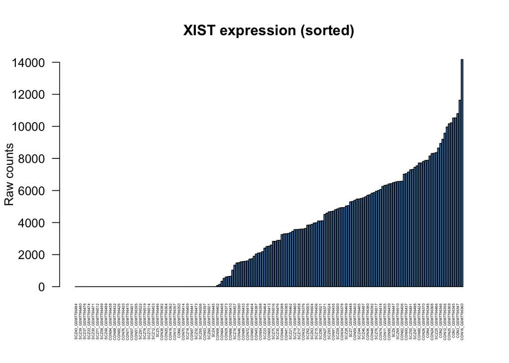

```r
barplot(
  sort(xist_counts),
  las = 2,
  cex.names = 0.3,
  main = "XIST expression (sorted)",
  ylab = "Raw counts",
  col = "steelblue"
)
```

I will also create a histogram

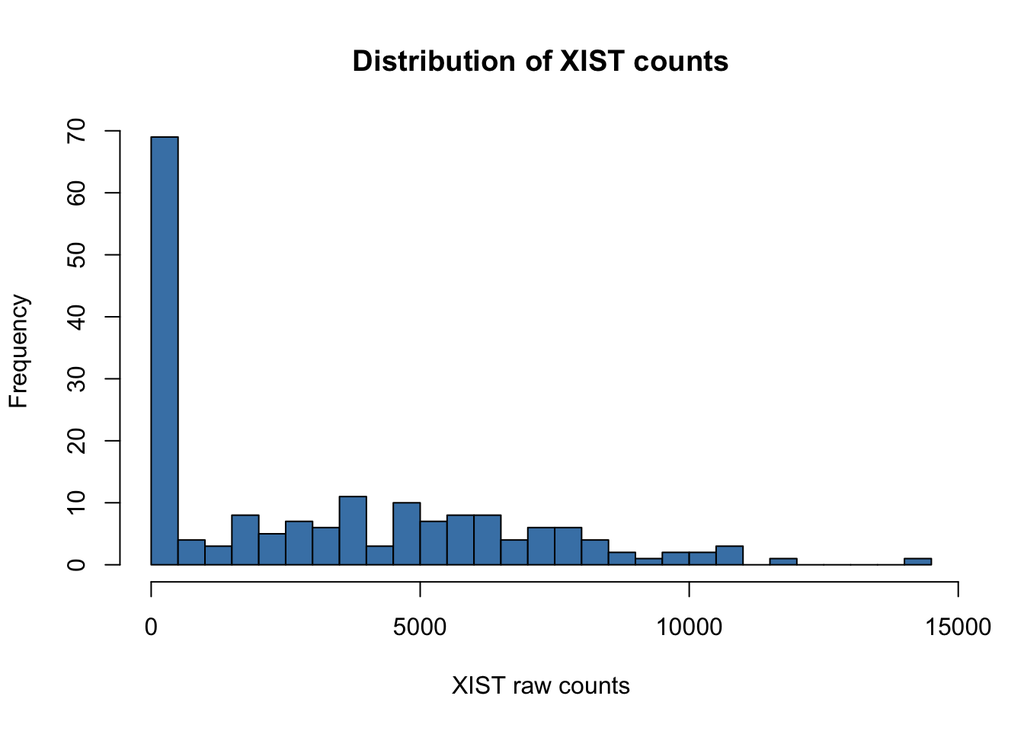

```r
hist(
  xist_counts,
  breaks = 30,
  main = "Distribution of XIST counts",
  xlab = "XIST raw counts",
  col = "steelblue"
)
```

```r
counts[1:5, 100]
```

```
##     DDX11L1      WASH7P   MIR6859-1 MIR1302-2HG   MIR1302-2
##           0           6           0           0           0
```

```r
counts[1:7, 100:101]
```

```
##             SCZ81_GSM7796522 SCZ80_GSM7796521
## DDX11L1                    0                1
## WASH7P                     6                4
## MIR6859-1                  0                0
## MIR1302-2HG                0                0
## MIR1302-2                  0                0
## FAM138A                    0                0
## OR4G4P                     0                0
```

```r
counts[1:7, c(100,102)]
```

```
##             SCZ81_GSM7796522 SCZ79_GSM7796520
## DDX11L1                    0                0
## WASH7P                     6               14
## MIR6859-1                  0                1
## MIR1302-2HG                0                0
## MIR1302-2                  0                0
## FAM138A                    0                0
## OR4G4P                     0                0
```

```r
xist_threshold <- 842

sex_assignment <- ifelse(
  xist_counts > xist_threshold,
  "Female",
  "Male"
)

table(sex_assignment)
```

```
## sex_assignment
## Female   Male
##    108     73
```

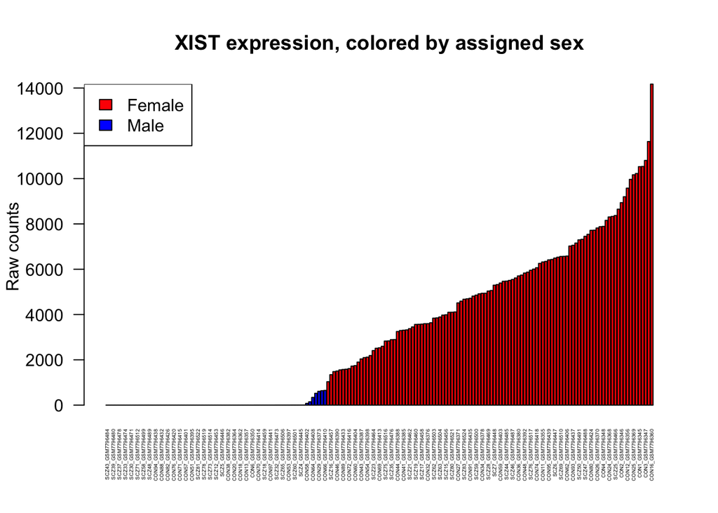

```r
colors <- ifelse(
  sex_assignment == "Female",
  "red",
  "blue"
)

barplot(
  sort(xist_counts),
  las = 2,
  cex.names = 0.3,
  main = "XIST expression, colored by assigned sex",
  ylab = "Raw counts",
  col = colors[order(xist_counts)]
)

legend(
  "topleft",
  legend = c("Female", "Male"),
  fill = c("red", "blue")
)
```

```r
xist_threshold <- 78

sex_assignment <- ifelse(
  xist_counts > xist_threshold,
  "Female",
  "Male"
)

table(sex_assignment)
```

```
## sex_assignment
## Female   Male
##    114     67
```

Mostly female. Need to ask Helena about the right threshold. ChatGPT said you need to do a midpoint between a big jump. But Perplexity AI and Claude AI stated that 78 was a fair threshold.

I next need to examine the Y-chromosome genes to evaluate whether the assignments were consistent.

```r
sex_table <- data.frame(
  sample = names(xist_counts),
  XIST_count = as.numeric(xist_counts),
  assigned_sex = unname(sex_assignment)
)

head(sex_table, 20)
```

```
##              sample XIST_count assigned_sex
## 1  SCZ47_GSM7796488       7451       Female
## 2  SCZ46_GSM7796487       5546       Female
## 3  SCZ45_GSM7796486       3453       Female
## 4  SCZ44_GSM7796485       5474       Female
## 5  SCZ43_GSM7796484          0         Male
## 6  SCZ42_GSM7796483       4914       Female
## 7  SCZ41_GSM7796482          0         Male
## 8  SCZ40_GSM7796481      10536       Female
## 9  SCZ39_GSM7796480          0         Male
## 10 SCZ38_GSM7796479          0         Male
## 11 SCZ37_GSM7796478          0         Male
## 12 SCZ36_GSM7796477        636       Female
## 13 SCZ35_GSM7796476       2891       Female
## 14 SCZ34_GSM7796475          0         Male
## 15 SCZ33_GSM7796474          0         Male
## 16 SCZ32_GSM7796473          2         Male
## 17 SCZ31_GSM7796472          0         Male
## 18 SCZ30_GSM7796471          0         Male
## 19 SCZ29_GSM7796470       2097       Female
## 20 SCZ28_GSM7796469       5035       Female
```

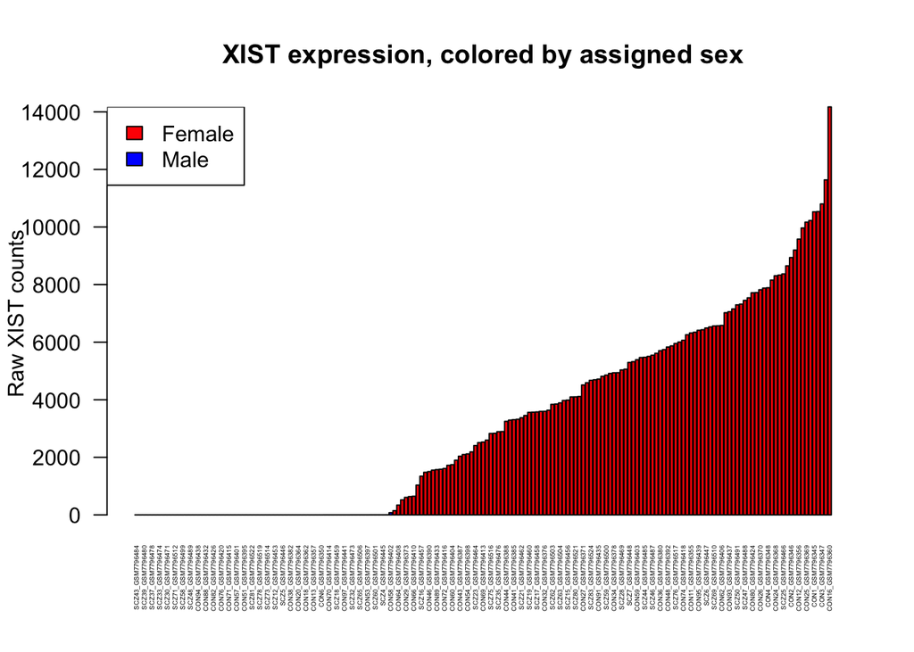

```r
colors <- ifelse(
  sex_assignment == "Female",
  "red",
  "blue"
)

barplot(
  sort(xist_counts),
  las = 2,
  cex.names = 0.3,
  main = "XIST expression, colored by assigned sex",
  ylab = "Raw XIST counts",
  col = colors[order(xist_counts)]
)

legend(
  "topleft",
  legend = c("Female", "Male"),
  fill = c("red", "blue")
)
```

### Validating assignments with Y-chromosome genes

Samples assigned male should generally express Y-linked genes, while samples assigned female should have little or no Y-linked expression. I am checking five Y linked genes to determine whether they support the XIST based assignments.

```r
y_genes <- c("RPS4Y1", "EIF1AY", "DDX3Y", "KDM5D", "UTY")

y_genes %in% rownames(counts)
```

```
## [1] TRUE TRUE TRUE TRUE TRUE
```

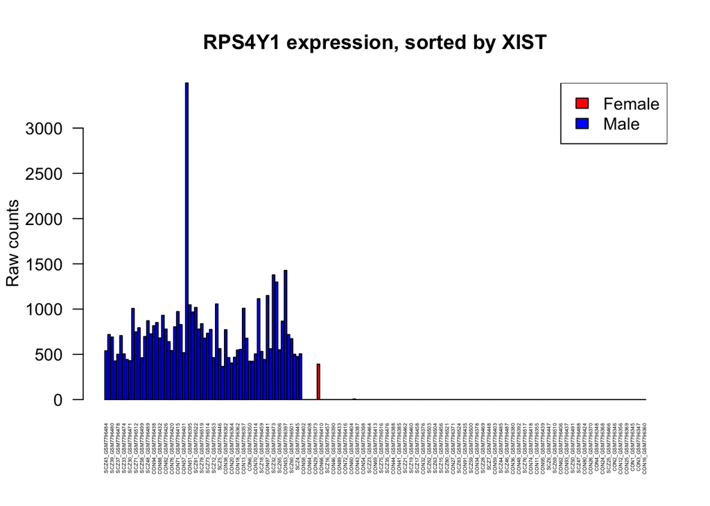

```r
if ("RPS4Y1" %in% rownames(counts)) {

  rps4y1_counts <- counts["RPS4Y1", ]

  barplot(
    rps4y1_counts[order(xist_counts)],
    las = 2,
    cex.names = 0.3,
    main = "RPS4Y1 expression, sorted by XIST",
    ylab = "Raw counts",
    col = colors[order(xist_counts)]
  )

  legend(
    "topright",
    legend = c("Female", "Male"),
    fill = c("red", "blue")
  )
}
```

All five Y-chromosome genes were present in the matrix. RPS4Y1 was strongly expressed in nearly all samples assigned male. However, one female assigned sample had noticeable RPS4Y1 expression. We should test more genes.

```r
plot_y_gene <- function(gene) {

  gene_counts <- counts[gene, ]

  barplot(
    gene_counts[order(xist_counts)],
    las = 2,
    cex.names = 0.3,
    main = paste(gene, "expression, sorted by XIST"),
    ylab = "Raw counts",
    col = colors[order(xist_counts)]
  )

  legend(
    "topright",
    legend = c("Female", "Male"),
    fill = c("red", "blue")
  )
}
```

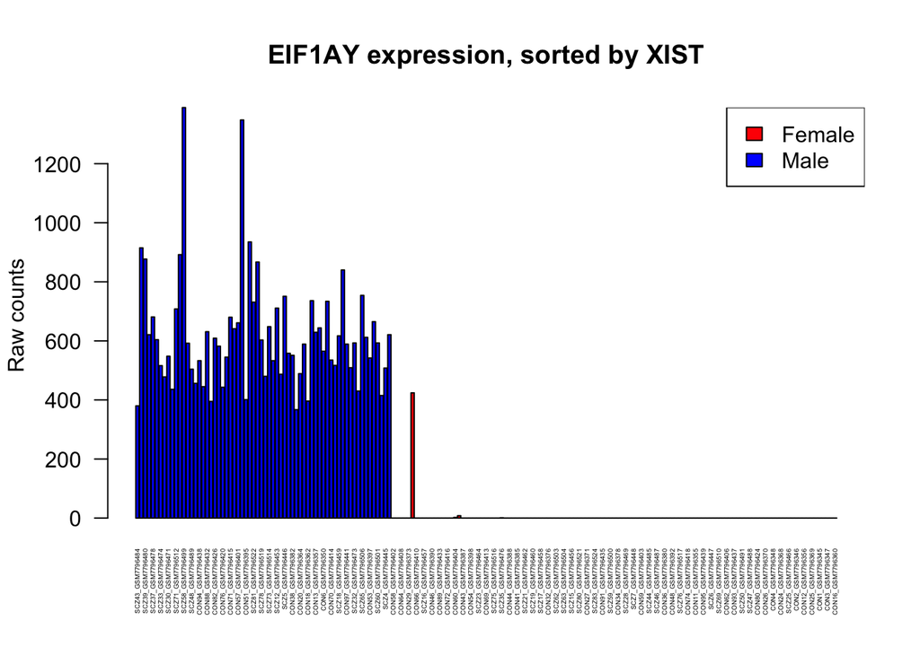

```r
plot_y_gene("EIF1AY")
```

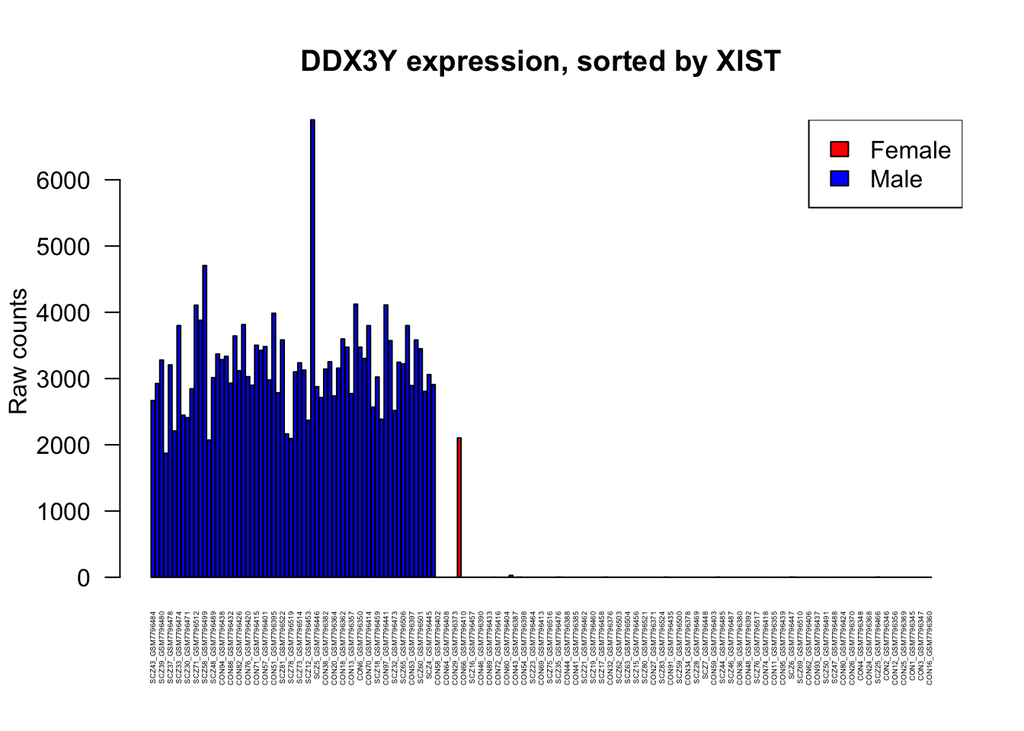

```r
plot_y_gene("DDX3Y")
```

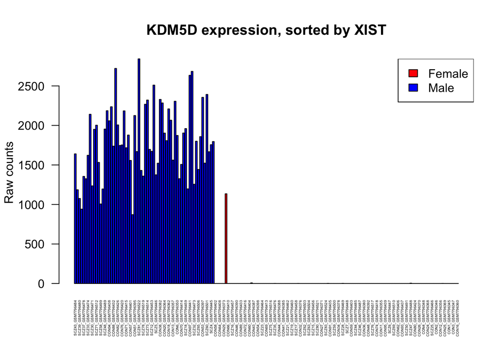

```r
plot_y_gene("KDM5D")
```

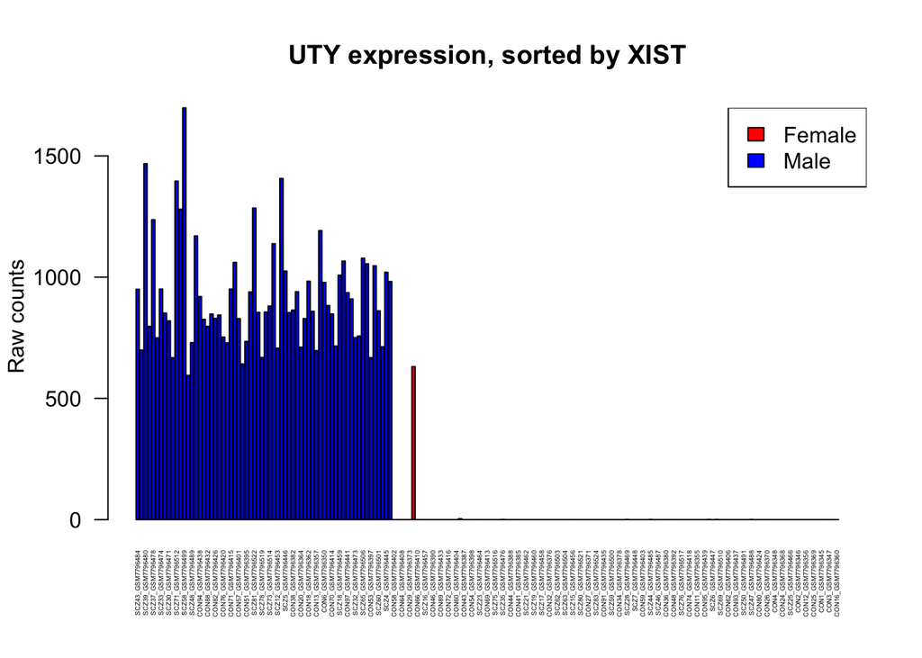

```r
plot_y_gene("UTY")
```

```r
validation_table <- data.frame(
  sample = colnames(counts),
  XIST = as.numeric(xist_counts),
  assigned_sex = unname(sex_assignment),
  RPS4Y1 = as.numeric(counts["RPS4Y1", ]),
  EIF1AY = as.numeric(counts["EIF1AY", ]),
  DDX3Y = as.numeric(counts["DDX3Y", ]),
  KDM5D = as.numeric(counts["KDM5D", ]),
  UTY = as.numeric(counts["UTY", ])
)

validation_table$Y_total <- rowSums(validation_table[, 4:8])

female_validation <- validation_table[
  validation_table$assigned_sex == "Female",
]

head(
  female_validation[
    order(female_validation$Y_total, decreasing = TRUE),
  ],
  10
)
```

```
##               sample XIST assigned_sex RPS4Y1 EIF1AY DDX3Y KDM5D UTY Y_total
## 12  SCZ36_GSM7796477  636       Female    392    424  2103  1135 631    4685
## 21  SCZ27_GSM7796468 1900       Female      7      8    29     8   4      56
## 13  SCZ35_GSM7796476 2891       Female      0      1     3     1   1       6
## 1   SCZ47_GSM7796488 7451       Female      0      0     0     4   1       5
## 130  SCZ3_GSM7796444 4693       Female      0      0     3     2   0       5
## 23  SCZ25_GSM7796466 8370       Female      0      0     4     0   0       4
## 42  SCZ54_GSM7796495 3596       Female      0      0     3     1   0       4
## 127  SCZ6_GSM7796447 6492       Female      0      0     4     0   0       4
## 19  SCZ29_GSM7796470 2097       Female      0      0     3     0   0       3
## 20  SCZ28_GSM7796469 5035       Female      0      0     0     2   1       3
```

SCZ36 was the only disagreement. Although its XIST count of 636 caused it to be initially assigned female, it strongly expressed all five Y-linked genes with a combined total of 4,685 counts. The next highest Y gene total among female-assigned samples was only 56.

```r
# Preserve the original XIST-only assignments
sex_assignment_xist <- sex_assignment

# Create the final validated assignments
sex_assignment_validated <- sex_assignment_xist
sex_assignment_validated["SCZ36_GSM7796477"] <- "Male"

table(sex_assignment_validated)
```

```
## sex_assignment_validated
## Female   Male
##    113     68
```

### Separating the matrix by sex assignment

I am separating the original counts matrix into female- and male-assigned samples using the XIST results validated with Y-chromosome genes.

```r
female_samples <- names(
  sex_assignment_validated[
    sex_assignment_validated == "Female"
  ]
)

male_samples <- names(
  sex_assignment_validated[
    sex_assignment_validated == "Male"
  ]
)

length(female_samples)
```

```
## [1] 113
```

```r
length(male_samples)
```

```
## [1] 68
```

```r
counts_female <- counts[, female_samples]
counts_male <- counts[, male_samples]

dim(counts_female)
```

```
## [1] 89118   113
```

```r
dim(counts_male)
```

```
## [1] 89118    68
```

The female matrix contained 89,118 features across 113 samples, while the male matrix contained the same 89,118 features across 68 samples. The two groups total 181 samples, confirming that every sample was included exactly once.

### Sex breakdown by condition

I am combining the validated sex assignments with the schizophrenia and control labels to determine the number of samples in each group.

```r
sex_condition <- data.frame(
  sample = colnames(counts),
  sex = unname(
    sex_assignment_validated[colnames(counts)]
  ),
  condition = ifelse(
    grepl("SCZ", colnames(counts)),
    "Schizophrenia",
    "Control"
  )
)

table(sex_condition$sex, sex_condition$condition)
```

```
##
##          Control Schizophrenia
##   Female      67            46
##   Male        30            38
```

```r
write.csv(
  sex_condition,
  "results/sex_assignments.csv",
  row.names = FALSE
)

saveRDS(
  counts_filtered,
  "results/dataset/counts_filtered.rds"
)

saveRDS(
  features_filtered,
  "results/dataset/features_filtered.rds"
)
```

```r
write.csv(
  sex_condition, file = "results/sex_assignments.csv",
  row.names = FALSE
)

saveRDS(
  counts_filtered,
  "results/dataset/counts_filtered.rds"
)

saveRDS(
  features_filtered,
  "results/dataset/features_filtered.rds"
)
```

## Part 4 Checkpoint: What I learned

The initial assignments were:

114 female 67 male

I then validated these assignments using five Y-chromosome genes:

All five genes were present in the matrix. Nearly all male-assigned samples strongly expressed the Y-linked genes, while nearly all female-assigned samples had little or no expression.

One sample, `SCZ36`, was initially assigned female because its XIST count was 636. However, it strongly expressed all five Y-linked genes, with a combined Y-gene count of 4,685. I reclassified this sample as male.

The final validated assignments were:

113 female 68 male

I separated the counts matrix into:

A female matrix with 89,118 features and 113 samples A male matrix with 89,118 features and 68 samples

The final breakdown by condition was:

Female Control - 67 Female SCZ - 46 Male Control - 30 Male SCZ - 38

## Part 6: Wrap Up

After speaking with Helena, I learned that R results can be displayed and saved in different ways. An R Notebook combines code, output, graphs, and written observations, while knitting turns the completed notebook into a shareable HTML file. We also discussed that sample sex should not be inferred from only one gene. I first used XIST to make initial assignments and then used five Y-chromosome markers to validate them. This showed the importance of using multiple methods to confirm a result and documenting the full process.